# 第五讲 统计学习基础与应用

# 0. 准备工作

```r
setwd("Ch05")
rm(list=ls())
install.packages("ISLR")
# 调用
library(ISLR)
library(tidyverse)
library(ggplot2)
```

# 1. 统计学习基本概念

## 1.2 相关概念比较

- [统计建模（statistical modeling）](https://en.wikipedia.org/wiki/Statistical_model)：统计模型是对数据分布（distribution）和数据生成过程（data-generating process）的数学描述。Kenneth Bollen认为“a model is a formal representation of a theory”。
- [机器学习（machine learning）](https://zh.wikipedia.org/wiki/%E6%9C%BA%E5%99%A8%E5%AD%A6%E4%B9%A0)：设计和分析一些让计算机可以自动“学习”的算法，即从数据中自动分析获得规律，并利用规律对未知数据进行预测的算法。虽然算法设计过程中也涉及统计学理论，但与统计学习相比，机器学习更关注可以实现的、行之有效的学习算法（如决策树、聚类、支持向量机、神经网络等）。

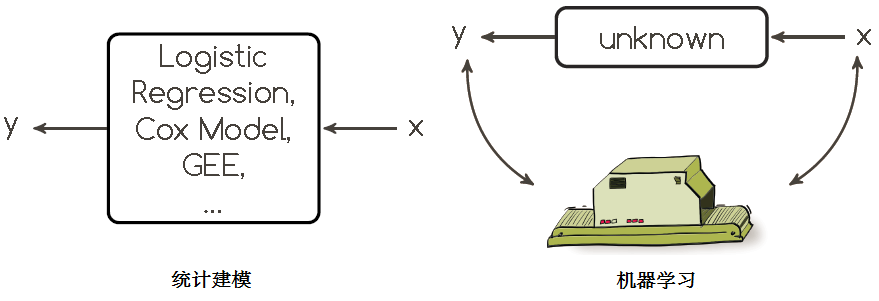

- [数据挖掘（data mining）](https://zh.wikipedia.org/wiki/%E6%95%B0%E6%8D%AE%E6%8C%96%E6%8E%98) ：从大量的数据中自动搜索隐藏于其中的知识和信息的过程，也称为数据库知识发现（Knowledge-Discovery in Databases, KDD）。数据挖掘在大数据采集和存储技术的基础上，通过统计分析、机器学习、在线分析处理、情报检索、专家系统和模式识别等诸多方法来实现具体的应用性目标。
- 小结：
  - 统计建模者认为世界可以用概率分布来逼近，统计建模的最终目的是获得数据的概率分布，并在此基础上进行统计推断。
  - 机器学习则不关心数据产生于什么分布，甚至认为这个世界运行的方式非常复杂、无法用概率分布来解释，因此或机器学习的目标是最小化预测误差的某种度量，它关注的是预测的精准性。
  - 从统计建模、统计学习、机器学习到数据挖掘，理论性要求下降、应用性要求上升。

# 2. 主成分分析（Principal Component Analysis）

## 2.1 思想与方法

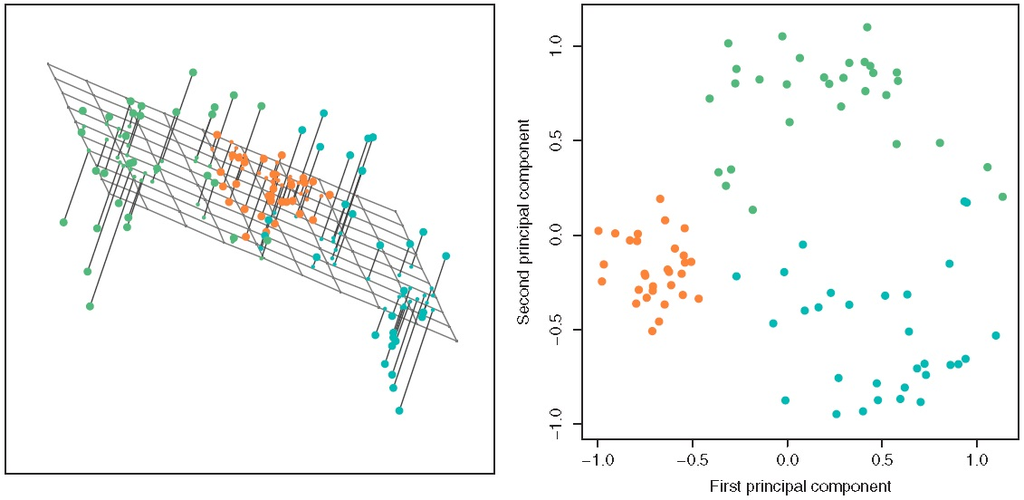

## 2.2 程序实现

```r
library(ISLR)                            # 调用数据包
dimnames(USArrests)                      # 美国各州犯罪数据指标
apply(USArrests,2,mean)                  # 查看各指标均值和方差
apply(USArrests,2, var)
```

在进行主成分分析之前，需要将各指标进行标准化，否则将直接影响分析结果：

$$X_{k}=\frac{X_{k}^{\text {raw}}-\bar{X}_{k}^{\text {raw}}}{\sigma_{k}^{\text {raw}}}$$

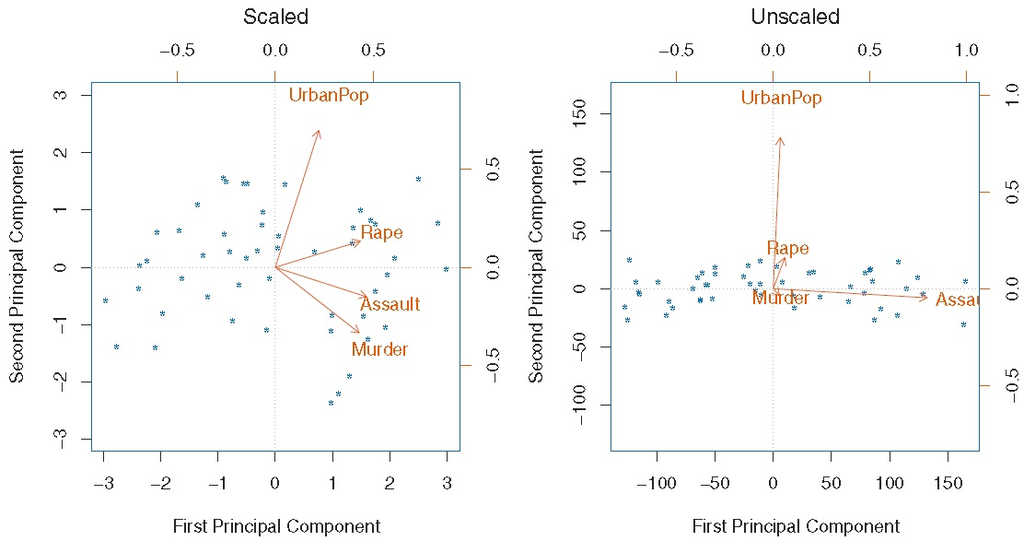

```r
pca.out=prcomp(USArrests, scale=TRUE)    # 主成分分析，用scale=T 进行标准化，或者用x=scale(x)手动处理
pca.out                                  # 主成分载荷矩阵 Phi
names(pca.out)                           # 其他可报告的变量
head(pca.out$x)                          # 主成分得分矩阵 Z
pve=pca.out$sdev^2/sum(pca.out$sdev^2)   # 每个主成分的方差解释比
plot(pve, type="l")
cumpve=cumsum(pve)                       # 累积方差解释比
plot(cumpve, type="l")
biplot(pca.out, scale=0)                 # 前两个主成分的双标图
```

# 3. 聚类分析

## 3.1 什么是聚类分析？

- 定义：聚类分析（clustering）是在一个数据集中寻找子群或类的技术。
- 与主成分分析的区别：
  - 主成分分析通过寻找方差最大的、变量的低维组合来提取信息（ $(K \rightarrow P)$;
  - 聚类分析则是寻找样本的同质子类 $(N \rightarrow K)$ 。

## 3.2 K均值聚类（K-means Clustering）

步骤1：将每个样本随机分配一个1到K的数字，即随机设定每个样本的初始类 $k_{i}^{0} \in\{1,2 \ldots K\}$

步骤2：重复下列操作，直到类的分配挺直为止： (1) 分别计算K个类的类中心 $\bar{x}_{k}=\frac{1}{\left|C_{k}\right|} \sum_{i \in C_{k}} x_{i}$ (2) 将每个样本分配到距离其最近的类中心所在的类中， $k_{i}=\underset{k}{\arg \min } \sum_{i \in C_{k}}\left\|x_{i}-\bar{x}_{k}\right\|$

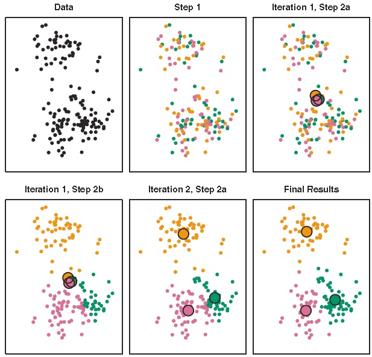

## 3.3 系统聚类（Hierarchical Clustering）

- 思想：自下而上，逐一将差异最小（距离最近）的样本合并归类。

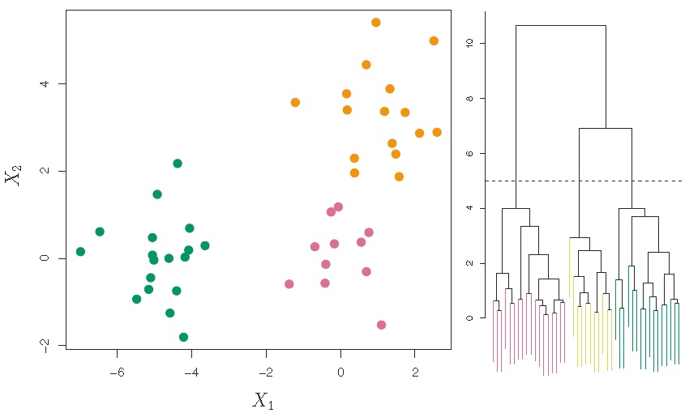

- 方法：

  步骤1：将每个样本作为一个类，即设定 $N$ 个初始类，并计算两两之间的差异度（如欧氏距离）；

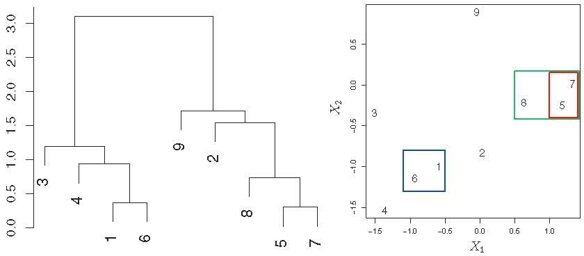

- 四种常用的类间差异度测量方法（最长距离、最短距离、类平均和重心法）：

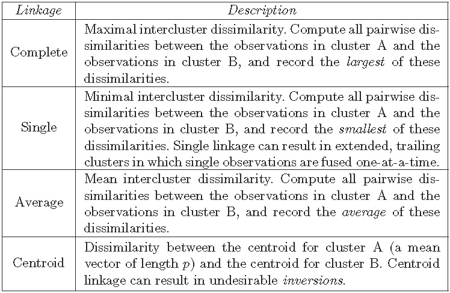

## 3.4 程序实现

```r
# K均值聚类
set.seed(101)
x=matrix(rnorm(100*2),100,2)           # 随机生成样本量为100、维度为2的数据集
xmean=matrix(rnorm(8,sd=4),4,2)        # 生成4组、2维的随机数
which=sample(1:4,100,replace=TRUE)     # 将100个样本随机分为4组
x=x+xmean[which,]                      # 通过改变4组数据均值的方式将其分开
plot(x,col=which,pch=19)               # 做图
km.out=kmeans(x,4,nstart=15)           # K均值聚类，K=4， 重复15次，报告最好结果
km.out
plot(x,col=km.out$cluster,cex=0.5,pch=1,lwd=2)
which=c(4,3,2,1)[which]                # 原数据分组倒序排列
km.result=data.frame(km=as.factor(km.out$cluster),which=as.factor(which), x)
table(km.result[,1:2])                 # 检查聚类结果，发现有两个样本匹配错了
km.result$miskm=(km.result$km!=km.result$which)
ggplot(km.result, aes(x=X1, y=X2, color=km, size=miskm)) +
  geom_point() +  theme_bw()
# 系统聚类
hc.complete=hclust(dist(x),method="complete") # 最长距离法
plot(hc.complete)
hc.single=hclust(dist(x),method="single")     # 最短距离法
plot(hc.single)
hc.average=hclust(dist(x),method="average")   # 类平均法
plot(hc.average)
hc.cut=cutree(hc.complete,4)                  # 基于最长距离法的聚类结果分为4组
table(hc.cut,which)                           # 与真实数据比较，有三个样本分错
result=data.frame(x)
result$hc=as.factor(c(2,3,4,1)[hc.cut])
result$mishc=(result$hc!=which)
ggplot(result, aes(x=X1, y=X2, color=hc, size=mishc)) +
  geom_point() +  theme_bw()
```

# 4. 金融数据应用

## 4.1 Tsay(2013) 多支个股的主成分分析

```r
rtn=read.table("m-5clog-9008.txt",header=T)  # 读取5支个股收益率数据
pca.cov = princomp(rtn)                      # 对协方差矩阵做主成分分析
summary(pca.cov)
pca.corr=princomp(rtn,cor=T)                 # 对相关系数矩阵做主成分分析
summary(pca.corr)
names(pca.corr)
pca2=prcomp(rtn, scale=T)                    # 用prcomp命令的结果与pca.corr一致
round(data.frame(pca.corr$sdev, pca2$sdev),3)
pca.corr$loadings
round(pca2$rotation,3)
```

## 4.2 聚类方法应用于信用卡数据

```r
# 数据读取
credit=read.csv("Credit.csv", header=T)[,-1]
str(credit)
# 将种族等因子变量转换为数值变量
credit= credit %>%
  mutate(Gender=as.numeric(as.character(Gender)==" Male"),
         Student=as.numeric(as.character(Student)=="Yes"),
         Married=as.numeric(as.character(Married)=="Yes"),
         Ethtype=as.numeric(Ethnicity))%>%
  dplyr::select(-Ethnicity)
# 聚类分析
km.out=kmeans(credit,3,nstart=15)
credit$km3=km.out$cluster
hc.out=hclust(dist(credit),method="complete")
hc.cut=cutree(hc.out,3)
credit$hc=hc.cut
# 比较两种聚类结果
table(hc.cut,km.out$cluster)
ggplot(credit,
       aes(x=Income, y=Rating, color=as.factor(hc), shape=as.factor(km3)))+
  geom_point() +  theme_bw()
```